# Estadística Multidimensional — Análisis Exploratorio Integral

### 10.2.2 Aplicado a cada variable

Siguiendo estos pasos procedemos a graficar la **DensidadKernel** para cada variable:

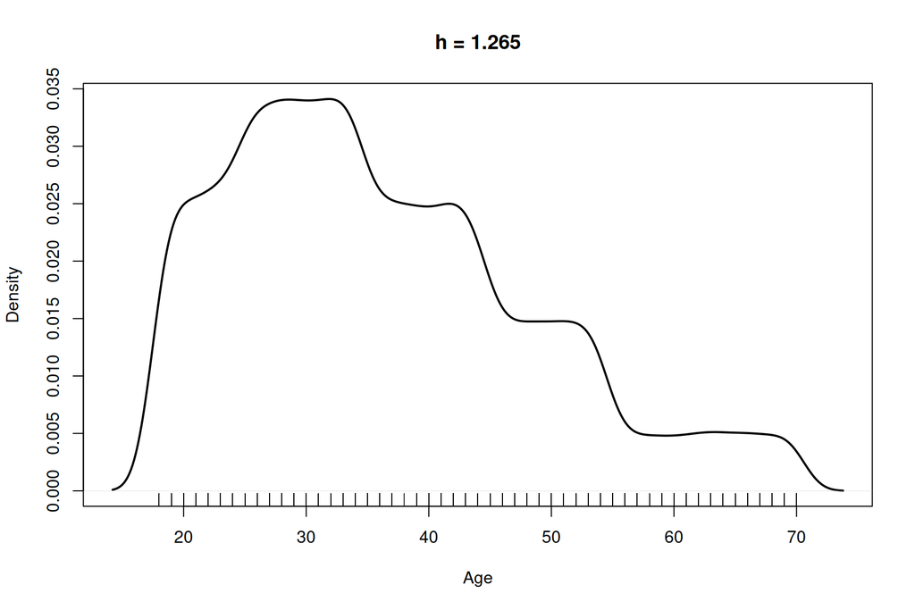

```r
credit_num <- names(credit)[sapply(credit, is.numeric)]

par(mfrow = c(1, 1))

for (credit_col in credit_num){

  var_aux <- credit[[credit_col]]
  h_aux <- bw.nrd0(var_aux)

  plot(density(var_aux, bw = h_aux), main = paste ("h =", round(h_aux, 4)), xlab   = credit_col, lwd = 2)
  rug(var_aux)

  # Análisis corto de la variable y de lo que muestra su curva de densidad
  cat(parrafo(credit_col, "dens"))

}
```

**Age** mide la edad del titular en años. La forma es casi simétrica con una leve inclinación hacia la derecha: la cartera se concentra entre los 27 y los 44 años y se adelgaza hacia los 70, porque hay pocos titulares mayores y ninguno menor de 18. La curva es la versión suavizada de ese histograma: alcanza su punto más alto cerca de 31.9 y desciende siguiendo la misma cola, sin depender del origen arbitrario de los intervalos.

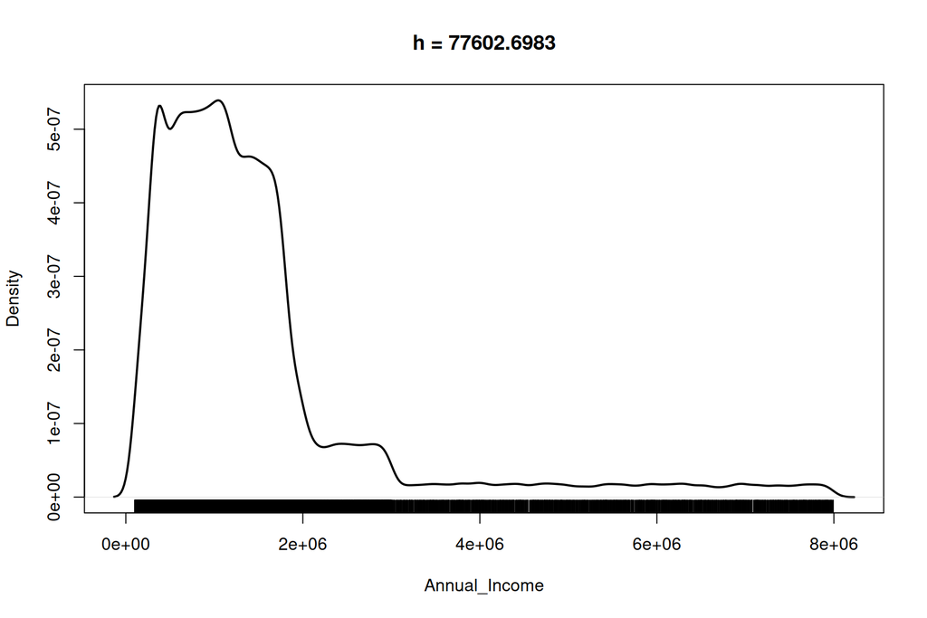

**Annual_Income** mide el ingreso anual declarado por el cliente. La cola larga hacia la derecha es lo esperable en cualquier variable de ingreso: la mayoría gana alrededor de la mediana y unos pocos ganan varias veces más, lo que empuja la media muy por encima de la mediana. La curva es la versión suavizada de ese histograma: alcanza su punto más alto cerca de 1.045.364 y desciende siguiendo la misma cola, sin depender del origen arbitrario de los intervalos.

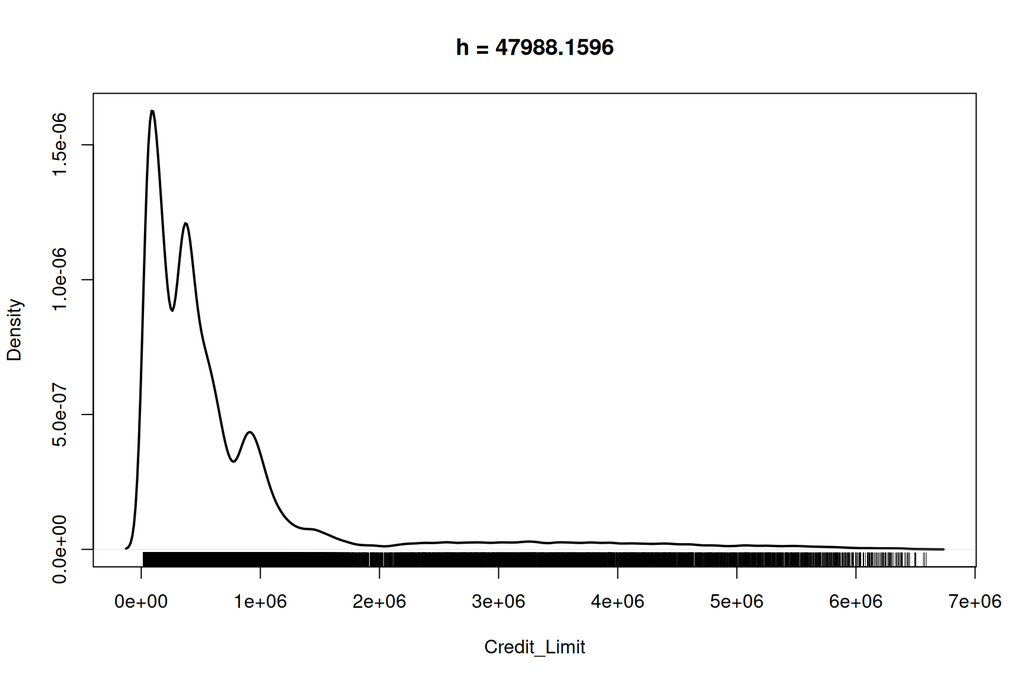

**Credit_Limit** mide el cupo total aprobado en la tarjeta. El cupo se asigna en función del ingreso, así que hereda la misma cola derecha; además solo toma valores redondeados (múltiplos de mil), por eso el histograma se ve escalonado y no continuo. La curva es la versión suavizada de ese histograma: alcanza su punto más alto cerca de 86.921.8 y desciende siguiendo la misma cola, sin depender del origen arbitrario de los intervalos.

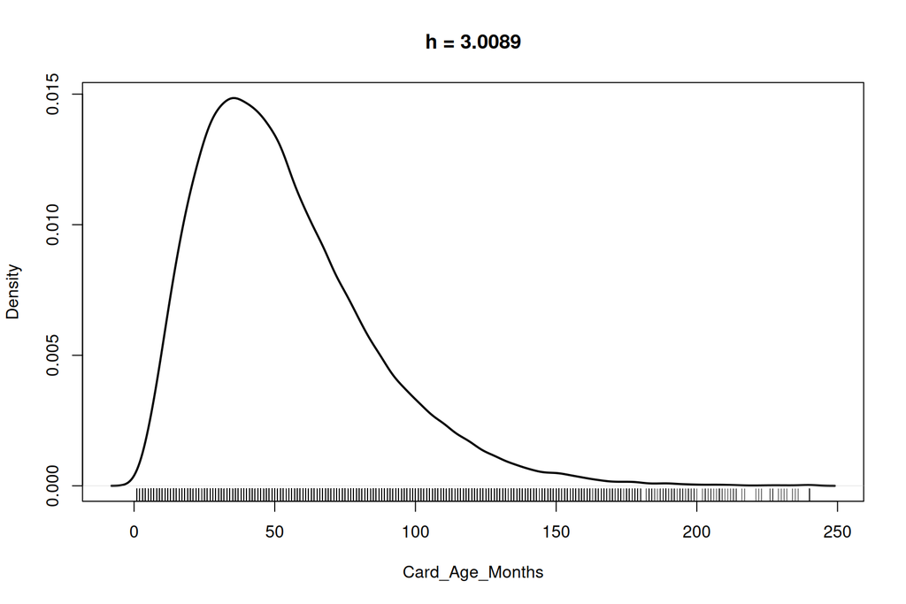

**Card_Age_Months** mide la antigüedad de la tarjeta en meses. Hay más tarjetas nuevas que antiguas, así que la masa se acumula en los primeros años y decae hacia los 240 meses: es el perfil de una cartera que sigue creciendo y captando clientes. La curva es la versión suavizada de ese histograma: alcanza su punto más alto cerca de 35.2 y desciende siguiendo la misma cola, sin depender del origen arbitrario de los intervalos.

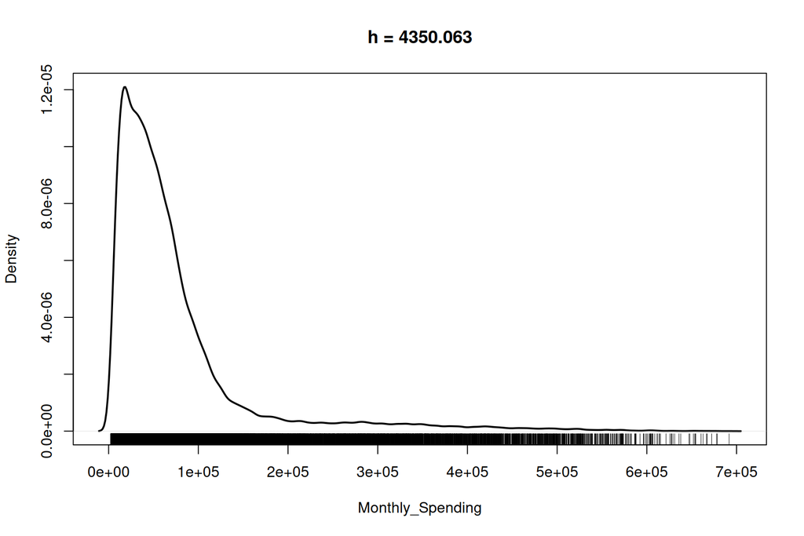

**Monthly_Spending** mide el gasto mensual total, que es la suma de las siete categorías de consumo. Al ser la suma de siete categorías que ya vienen sesgadas a la derecha, acumula todas esas colas: la mayoría gasta cerca de la mediana y un grupo pequeño gasta un orden de magnitud más. La curva es la versión suavizada de ese histograma: alcanza su punto más alto cerca de 18.591.7 y desciende siguiendo la misma cola, sin depender del origen arbitrario de los intervalos.

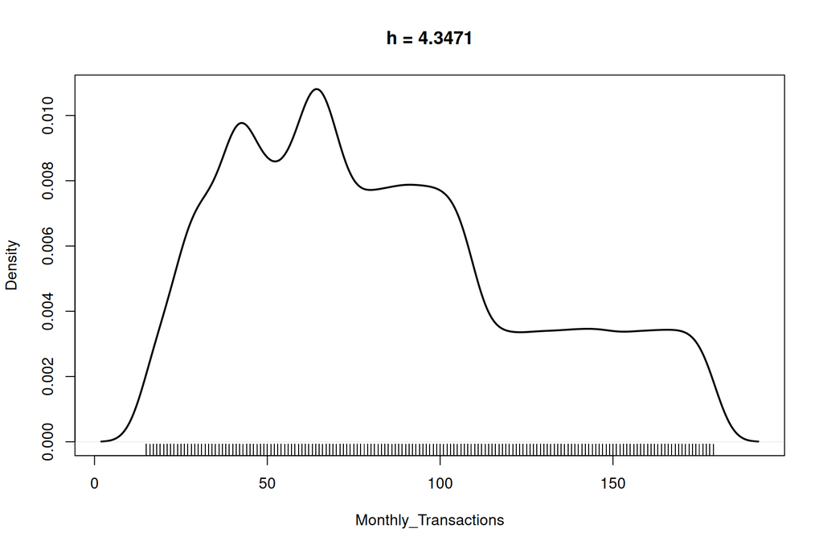

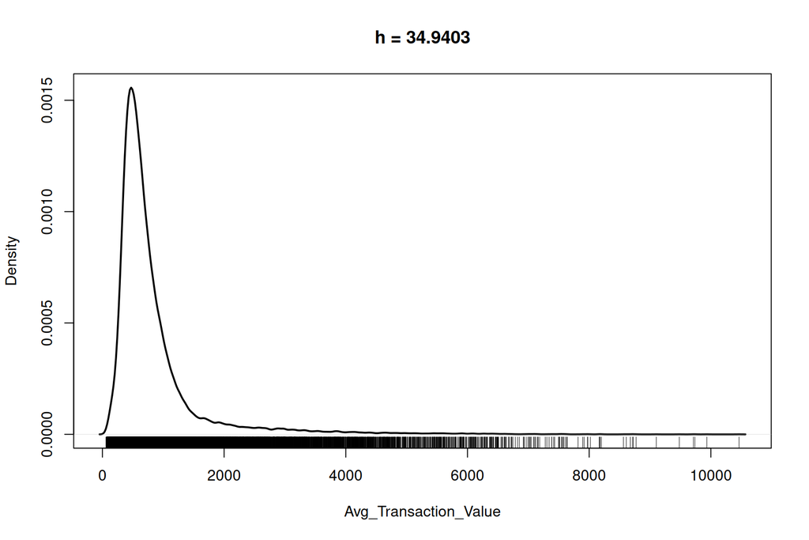

**Avg_Transaction_Value** mide el ticket promedio, es decir el gasto mensual dividido entre el número de transacciones. Es un cociente entre dos variables, y como el numerador tiene cola derecha y el denominador está acotado, el resultado queda fuertemente sesgado: dominan los tickets pequeños del día a día y unos pocos compradores de tickets altos estiran la cola. La curva es la versión suavizada de ese histograma: alcanza su punto más alto cerca de 472.3 y desciende siguiendo la misma cola, sin depender del origen arbitrario de los intervalos.

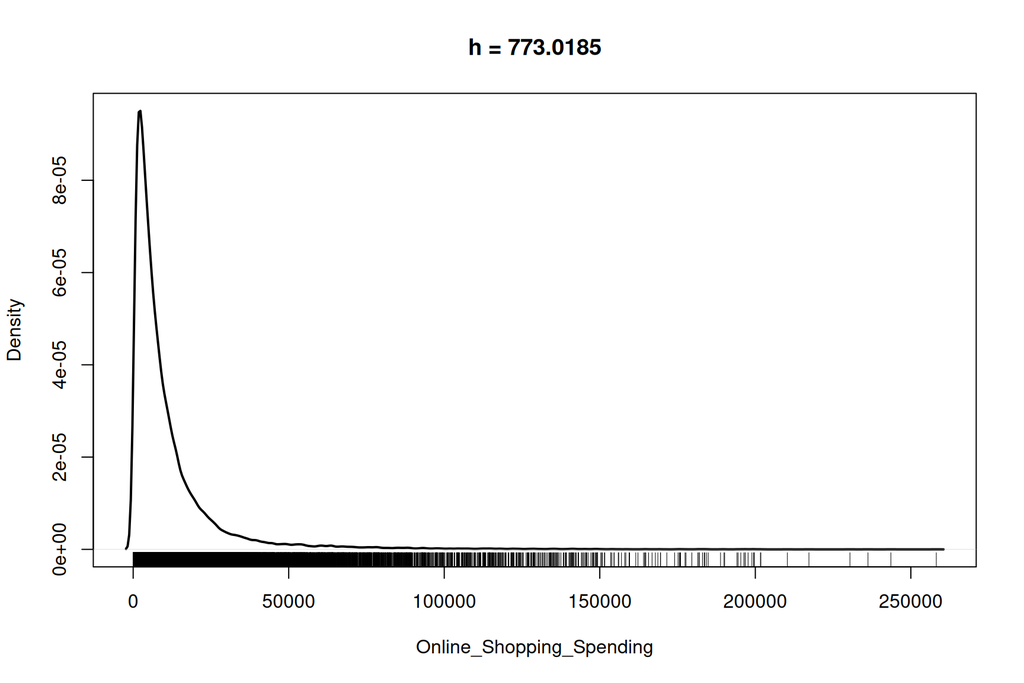

**Online_Shopping_Spending** mide el gasto mensual en compras por internet. Como todo gasto por categoría, la mayoría de clientes gasta poco y unos pocos gastan mucho, lo que produce el pico pegado al origen y la cola larga hacia la derecha. La curva es la versión suavizada de ese histograma: alcanza su punto más alto cerca de 2.323.4 y desciende siguiendo la misma cola, sin depender del origen arbitrario de los intervalos.

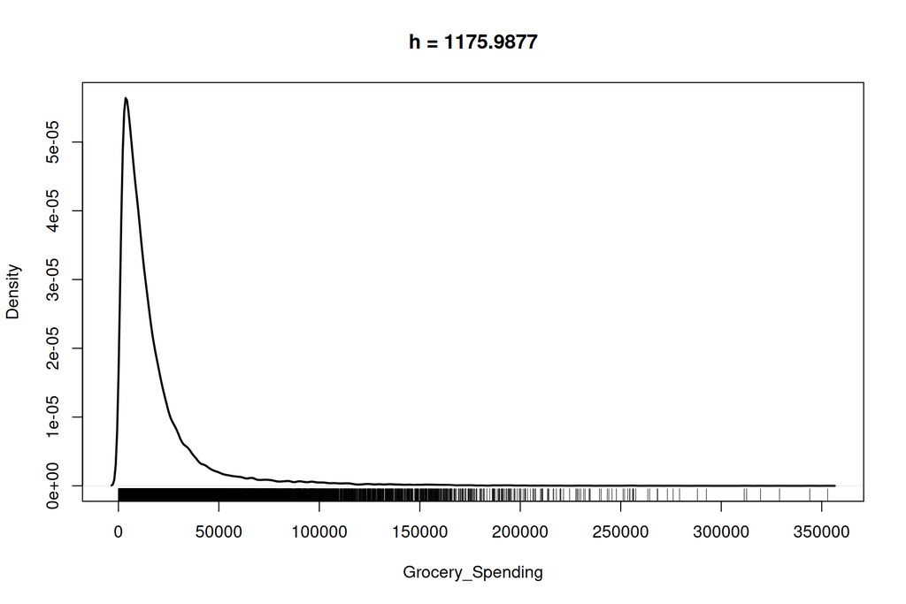

**Grocery_Spending** mide el gasto mensual en supermercado. Es la categoría con la mediana más alta de todas: el mercado es un gasto recurrente que casi todos hacen, por eso el pico está más desplazado del origen que en las demás categorías, aunque conserva la cola derecha. La curva es la versión suavizada de ese histograma: alcanza su punto más alto cerca de 3.599.8 y desciende siguiendo la misma cola, sin depender del origen arbitrario de los intervalos.

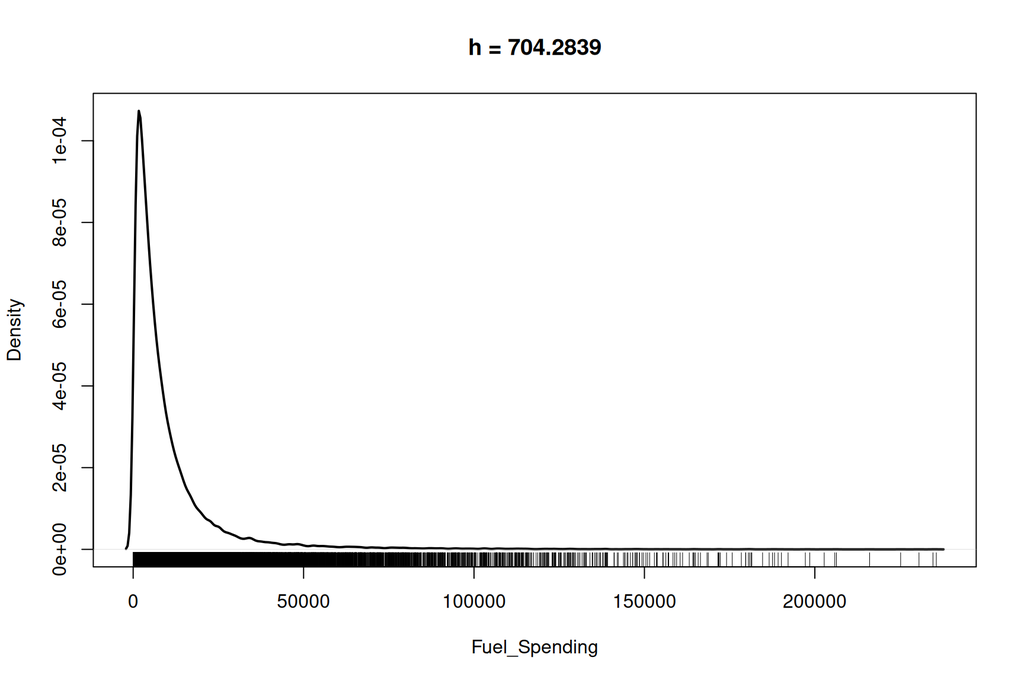

**Fuel_Spending** mide el gasto mensual en combustible. El gasto en combustible depende de si el cliente tiene vehículo y cuánto se desplaza, así que convive un grupo grande de gasto bajo con una minoría de gasto alto que alarga la cola. La curva es la versión suavizada de ese histograma: alcanza su punto más alto cerca de 1.653.1 y desciende siguiendo la misma cola, sin depender del origen arbitrario de los intervalos.

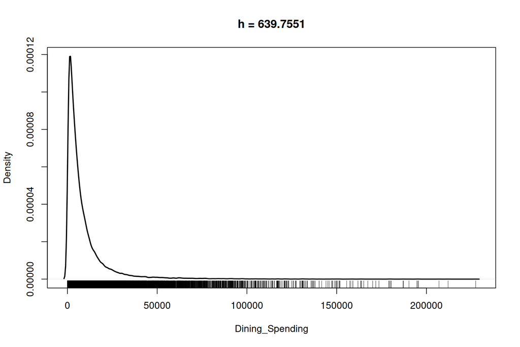

**Dining_Spending** mide el gasto mensual en restaurantes. Comer fuera es un gasto discrecional: la mayoría lo hace de forma moderada y una minoría concentra montos muy altos, de ahí el sesgo pronunciado a la derecha. La curva es la versión suavizada de ese histograma: alcanza su punto más alto cerca de 1.707.2 y desciende siguiendo la misma cola, sin depender del origen arbitrario de los intervalos.

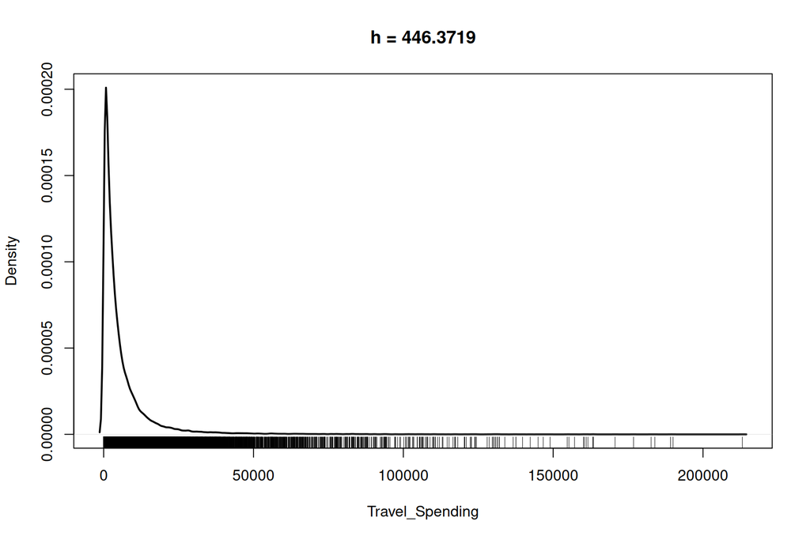

**Travel_Spending** mide el gasto mensual en viajes. Es el gasto más esporádico de todos (la mediana es la más baja de las categorías): la mayoría viaja poco o nada en el mes, y los pocos que viajan lo hacen con montos grandes, lo que produce la cola más larga del grupo. La curva es la versión suavizada de ese histograma: alcanza su punto más alto cerca de 772.7 y desciende siguiendo la misma cola, sin depender del origen arbitrario de los intervalos.

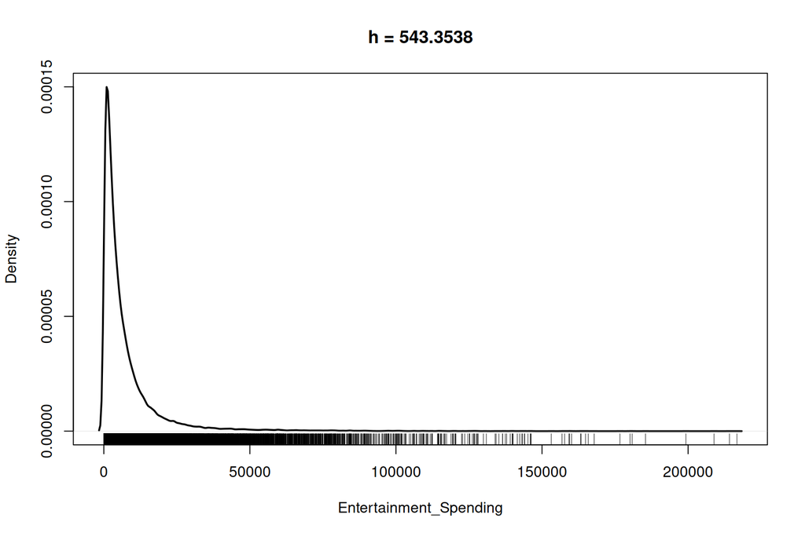

**Entertainment_Spending** mide el gasto mensual en entretenimiento. Gasto discrecional y ocasional: se concentra en montos bajos con una cola derecha marcada correspondiente a quienes consumen ocio de forma intensiva. La curva es la versión suavizada de ese histograma: alcanza su punto más alto cerca de 954.3 y desciende siguiendo la misma cola, sin depender del origen arbitrario de los intervalos.

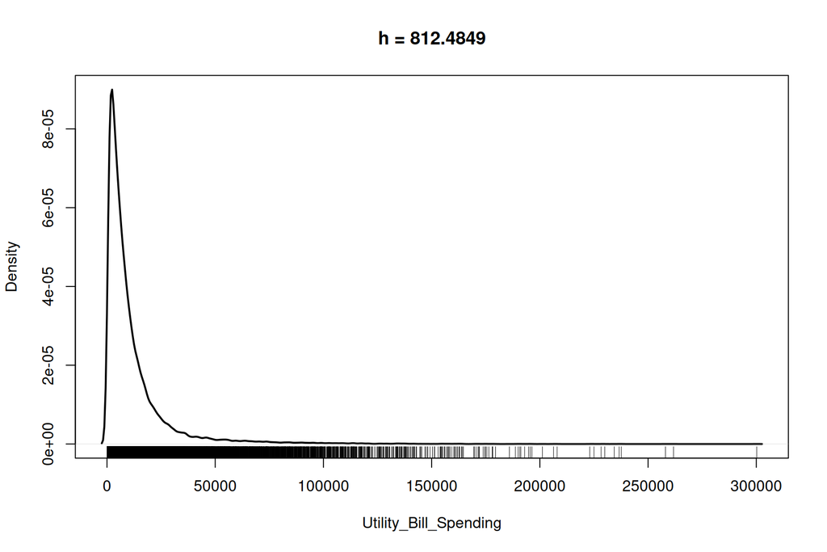

**Utility_Bill_Spending** mide el gasto mensual en servicios públicos pagados con la tarjeta. Domiciliar los servicios públicos en la tarjeta es una práctica frecuente pero de monto acotado, así que la masa está en valores bajos y la cola derecha viene de hogares con facturas altas. La curva es la versión suavizada de ese histograma: alcanza su punto más alto cerca de 2.358 y desciende siguiendo la misma cola, sin depender del origen arbitrario de los intervalos.

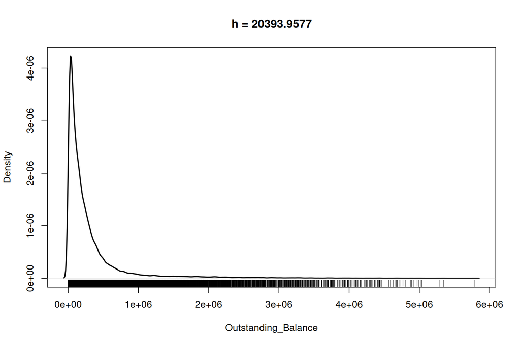

**Outstanding_Balance** mide el saldo que el cliente aún debe. La deuda pendiente sigue la misma lógica del gasto y del cupo: casi todos deben montos moderados y unos pocos arrastran saldos muy grandes, lo que estira la cola derecha. La curva es la versión suavizada de ese histograma: alcanza su punto más alto cerca de 32.949.3 y desciende siguiendo la misma cola, sin depender del origen arbitrario de los intervalos.

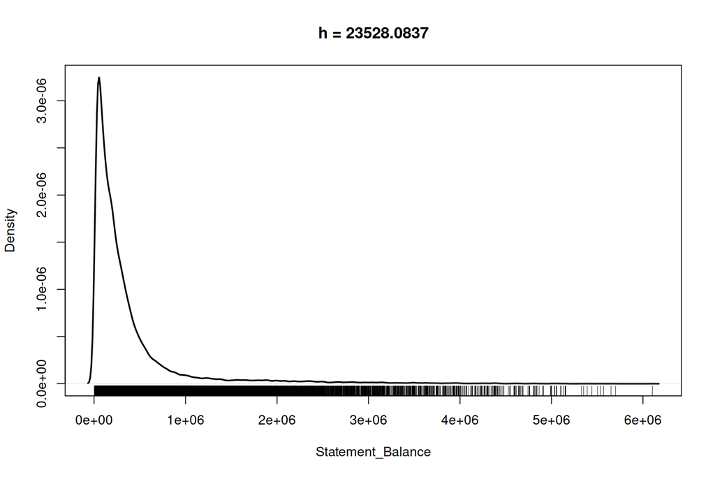

**Statement_Balance** mide el saldo facturado en el último corte del extracto. Es prácticamente la misma magnitud que el saldo pendiente medida en el corte de facturación, por eso su forma es casi idéntica a la de aquella variable. La curva es la versión suavizada de ese histograma: alcanza su punto más alto cerca de 55.686.7 y desciende siguiendo la misma cola, sin depender del origen arbitrario de los intervalos.

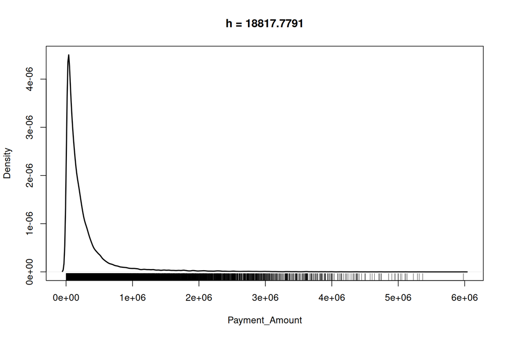

**Payment_Amount** mide el monto que el cliente pagó en el mes. El pago es proporcional a lo facturado, así que reproduce la forma sesgada del saldo: pagos moderados en la mayoría y pagos muy grandes en la minoría con saldos altos. La curva es la versión suavizada de ese histograma: alcanza su punto más alto cerca de 39.820.1 y desciende siguiendo la misma cola, sin depender del origen arbitrario de los intervalos.

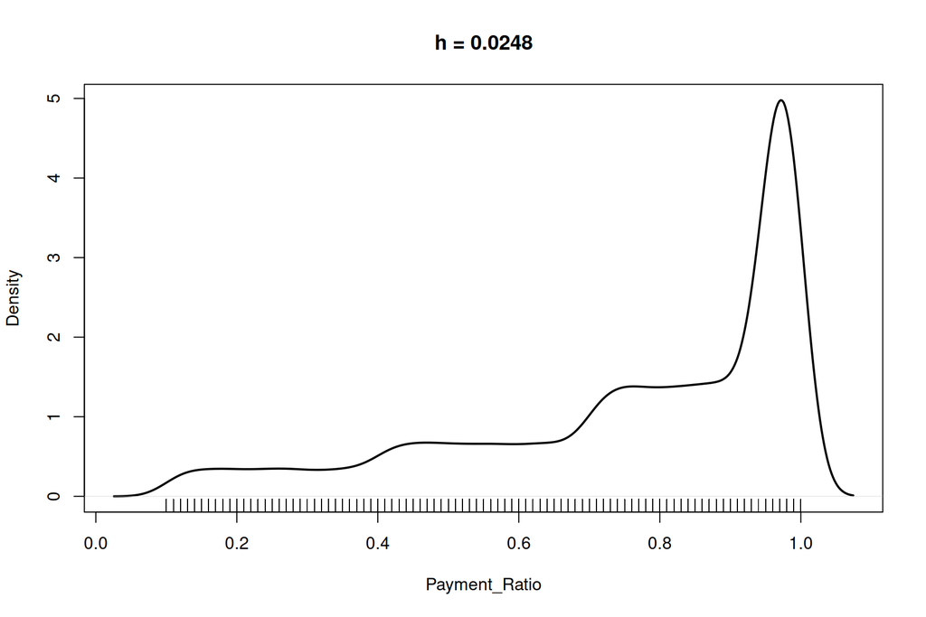

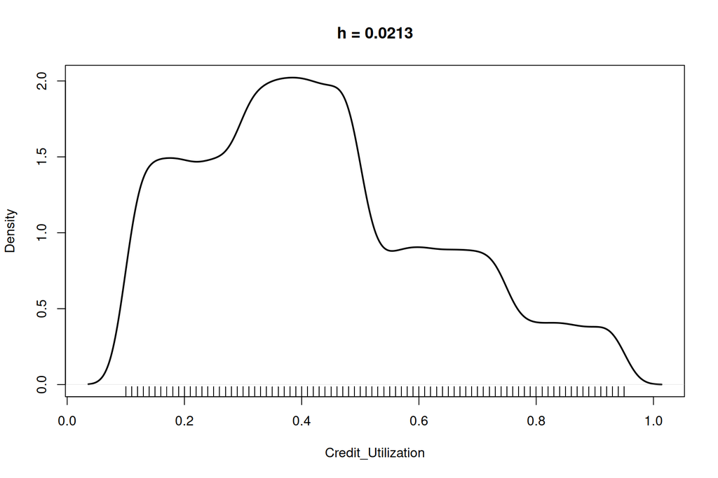

**Credit_Utilization** mide la proporción del cupo que el cliente tiene usada. Es una proporción acotada entre 0 y 1 por construcción, y las políticas de cupo evitan que los clientes lleguen al tope, por eso la forma es compacta, sin colas y sin ningún dato fuera de los bigotes. La curva es la versión suavizada de ese histograma: alcanza su punto más alto cerca de 0.4 y desciende siguiendo la misma cola, sin depender del origen arbitrario de los intervalos.

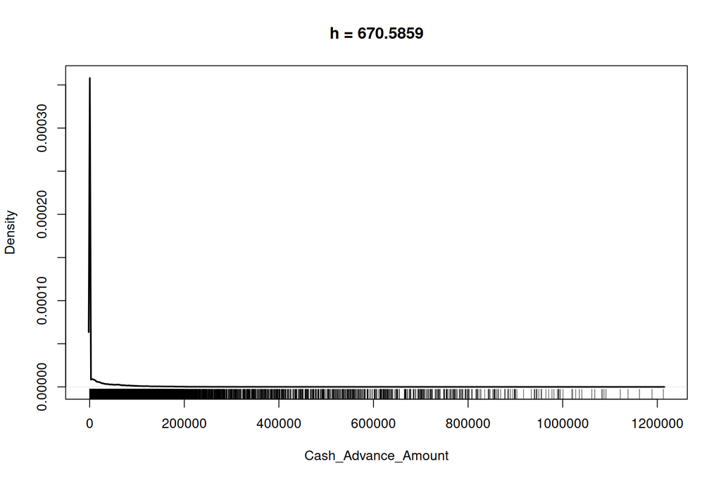

**Cash_Advance_Amount** mide el monto retirado como avance en efectivo. Más de la mitad de los clientes nunca hace avances, así que la distribución tiene un bloque enorme en cero y una cola larga formada por la minoría que sí los usa: es una variable inflada en cero, no una distribución continua clásica. La curva es la versión suavizada de ese histograma: alcanza su punto más alto cerca de 369.6 y desciende siguiendo la misma cola, sin depender del origen arbitrario de los intervalos.

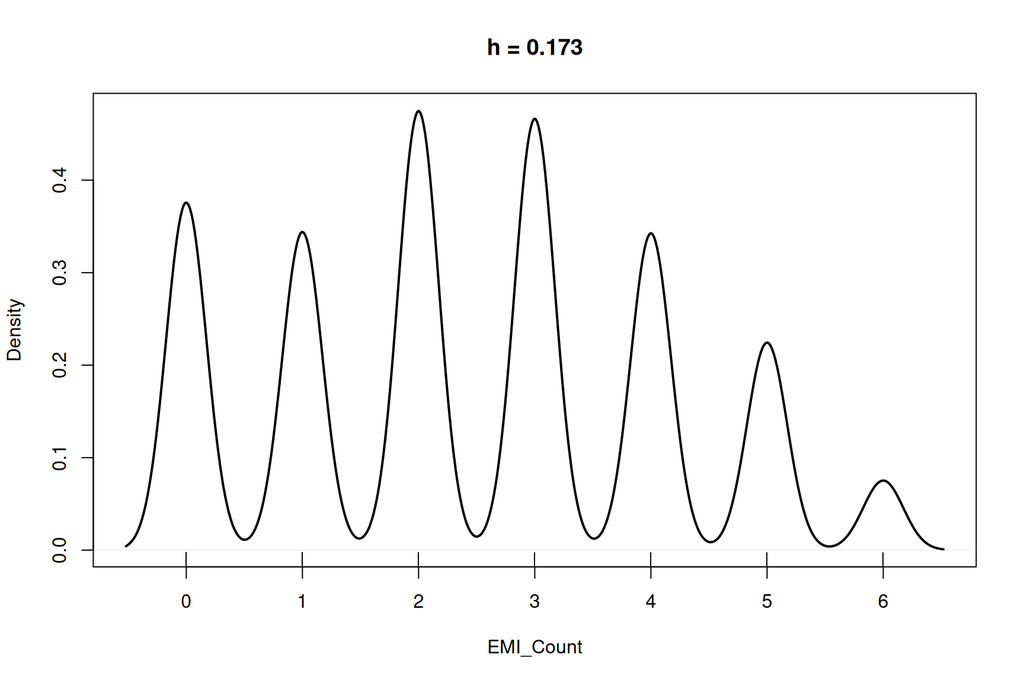

**EMI_Count** mide el número de compras diferidas a cuotas que el cliente tiene vigentes. Solo toma siete valores enteros (de 0 a 6 cuotas vigentes), por eso el histograma se ve como barras separadas y no como una curva: es un conteo discreto de rango muy corto. La curva es la versión suavizada de ese histograma: alcanza su punto más alto cerca de 2 y desciende siguiendo la misma cola, sin depender del origen arbitrario de los intervalos.

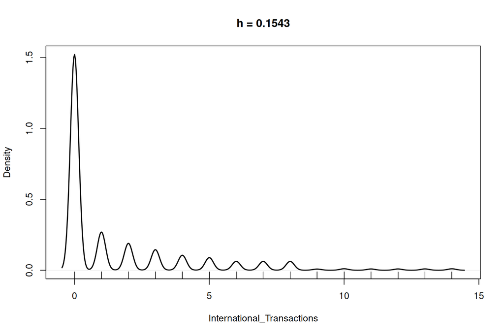

**International_Transactions** mide el número de compras hechas en el exterior. La mayoría de clientes no compra en el exterior, así que el valor típico es cero y las pocas decenas de compras internacionales aparecen como cola derecha discreta. La curva es la versión suavizada de ese histograma: alcanza su punto más alto cerca de 0 y desciende siguiendo la misma cola, sin depender del origen arbitrario de los intervalos.

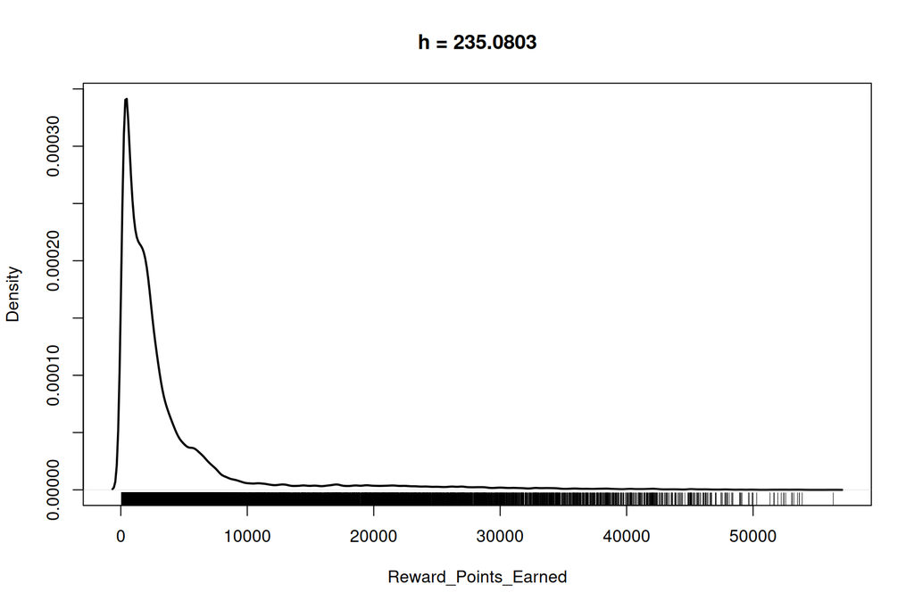

**Reward_Points_Earned** mide los puntos de recompensa acumulados, que el banco calcula a partir del gasto. Los puntos se calculan como función del gasto, así que la gráfica es esencialmente la del gasto mensual reescalada: mismo pico bajo y misma cola derecha. La curva es la versión suavizada de ese histograma: alcanza su punto más alto cerca de 468.1 y desciende siguiendo la misma cola, sin depender del origen arbitrario de los intervalos.

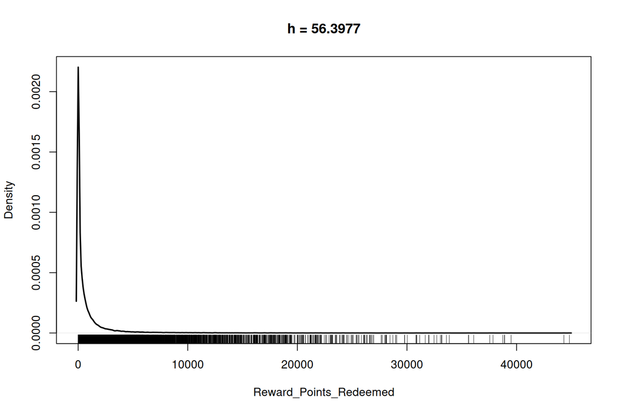

**Reward_Points_Redeemed** mide los puntos de recompensa que el cliente ya redimió. Muchos clientes acumulan puntos pero no los redimen, por eso hay una acumulación en cero y una cola derecha correspondiente a quienes sí los usan, normalmente en redenciones grandes y puntuales. La curva es la versión suavizada de ese histograma: alcanza su punto más alto cerca de 7.5 y desciende siguiendo la misma cola, sin depender del origen arbitrario de los intervalos.

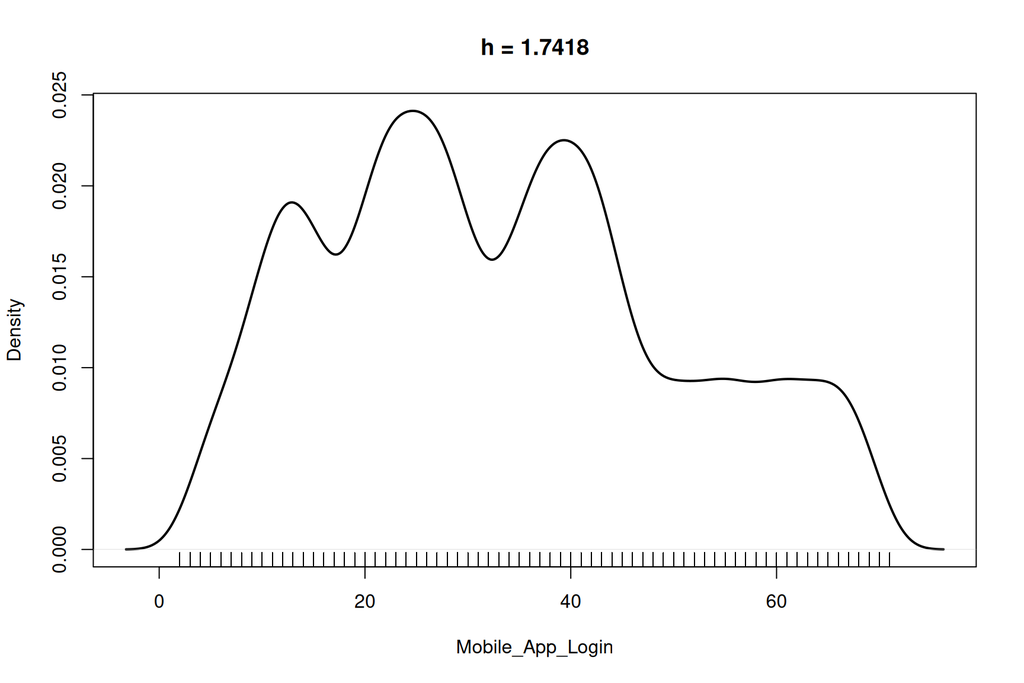

**Mobile_App_Login** mide el número de ingresos del cliente a la aplicación móvil en el mes. Es un conteo acotado de sesiones al mes (entre 2 y 71) y refleja un hábito de consulta bastante uniforme, así que la forma es casi simétrica y sin atípicos. La curva es la versión suavizada de ese histograma: alcanza su punto más alto cerca de 24.6 y desciende siguiendo la misma cola, sin depender del origen arbitrario de los intervalos.

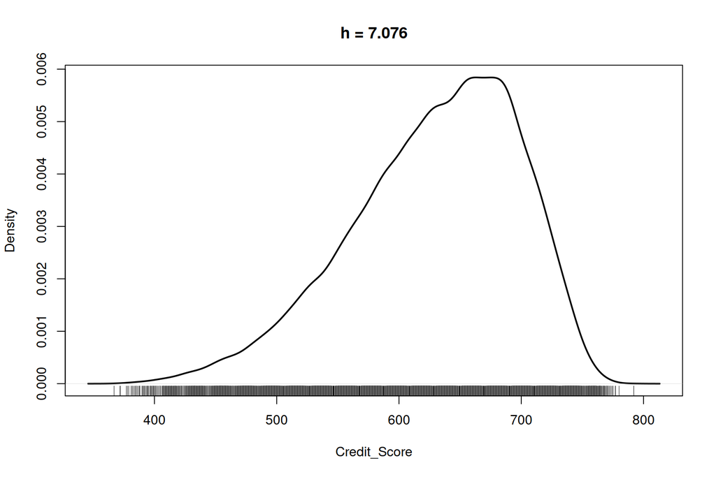

Como podemos observar con las graficas de **Densidad de Kernel** en los lugares donde se encuentran la mayor cantidad de datos es donde la curva o montaña crece e inversamente donde menos datos existen es donde esta misma decrece.

# 11 Conclusiones Ánalisis Multivariante Semana 4

1. **Densidad de Kernel:** La gráfica de Densidad de Kernel es otro modo de nosotros poder observar y analizar la distribucion que tienen los datos de las diferentes variables, podemos ver donde se encuentra la mayor cantidad de datos como tambien donde no existen casi datos, la gran diferencia con los histogramas o boxplots es que aqui no es necesario escoger un origen arbitrario o por conveniencia, aquí todo depende el ancho de banda $h$ el cual es un valor que definimos utilizando la formula o la funcion que trae R.

# 12 Módulo 8: Verificación de la Matriz para la Distancia de Mahalanobis

Antes de calcular covarianzas y distancias de Mahalanobis es necesario verificar que la submatriz numérica sea invertible. La siguiente función revisa los cinco puntos críticos: variables numéricas utilizadas, relación $n/p$, datos faltantes, existencia de estructura correlacional y redundancia (número de condición sobre datos estandarizados).

```r
revisar <- function(ruta, quitar = character(0)) {
  d <- read.csv(ruta)
  X <- d[, sapply(d, is.numeric), drop = FALSE]
  X <- X[, !(names(X) %in% quitar), drop = FALSE]
  n <- nrow(X); p <- ncol(X)

  cat("=====", ruta, "=====\n")
  cat("1. variables numéricas usadas:", p, "\n   ", paste(names(X), collapse = ", "), "\n\n")
  cat("2. n =", n, "| p =", p, "| n/p =", round(n/p, 1),
      ifelse(n/p >= 10, " OK", ifelse(n/p >= 5, " justo", " PROBLEMA")), "\n\n")
  cat("3. faltantes:", round(100*mean(is.na(X)), 1), "% | filas completas:",
      sum(complete.cases(X)), ifelse(sum(complete.cases(X)) >= 100, " OK", " PROBLEMA"), "\n\n")

  R <- cor(X, use = "pairwise.complete.obs"); diag(R) <- NA
  rmax <- max(abs(R), na.rm = TRUE)
  cat("4. |r| máxima:", round(rmax, 2),
      ifelse(rmax >= 0.5, " OK", ifelse(rmax >= 0.3, " justo", " PROBLEMA")), "\n")
  cat("   pares con |r|>0.5:", sum(abs(R) > 0.5, na.rm = TRUE)/2, "\n\n")

  Xs <- scale(X)   # estandarizar: evita que la escala infle el numero de condicion
  S <- cov(Xs, use = "pairwise.complete.obs")
  vp <- eigen(S)$values
  cond <- max(vp)/min(vp)
  cat("5. número de condición (sobre datos estandarizados):", format(cond, digits = 3),
      ifelse(cond < 1000, " OK", ifelse(cond < 1e5, " revisar", " REDUNDANCIA")), "\n")
  if (cond >= 1000) {
    R2 <- abs(cor(X, use = "pairwise.complete.obs")); diag(R2) <- 0
    par <- which(R2 > 0.95, arr.ind = TRUE)
    if (nrow(par) > 0) {
      cat("   pares casi idénticos:\n")
      for (i in seq_len(nrow(par))) if (par[i,1] < par[i,2])
        cat("    ", names(X)[par[i,1]], "<->", names(X)[par[i,2]], "\n")
    }
  }
  invisible(NULL)
}


revisar("bronze/synthetic_credit_card_customer_behavior_dataset.csv",
        quitar = c("Monthly_Spending", "Payment_Ratio", "Credit_Utilization", "Reward_Points_Earned", "Outstanding_Balance"))
```

```
#> ===== bronze/synthetic_credit_card_customer_behavior_dataset.csv =====
#> 1. variables numéricas usadas: 21
#>     Age, Annual_Income, Credit_Limit, Card_Age_Months, Monthly_Transactions, Avg_Transaction_Value, Online_Shopping_Spending, Grocery_Spending, Fuel_Spending, Dining_Spending, Travel_Spending, Entertainment_Spending, Utility_Bill_Spending, Statement_Balance, Payment_Amount, Cash_Advance_Amount, E…
#>
#> 2. n = 50000 | p = 21 | n/p = 2381  OK
#>
#> 3. faltantes: 0 % | filas completas: 50000  OK
#>
#> 4. |r| máxima: 0.97  OK
#>    pares con |r|>0.5: 75
#>
#> 5. número de condición (sobre datos estandarizados): 560  OK
```